# Is there a correlation between freedom and happiness? Is the ‘free world’ population happier than the population in communist countries?

By: Ateika Samuel IS 362 - Final Project

## Overview

In this study, we will be evaluating if there is a correlation between happiness and freedom. Moreover, we will also assess if the 'free world' is happier than the communist countries. We often associate happiness with a few contributing factors, such as freedom & money. For example, we often believe that a country where citizens are free to make life choices would be happier than a country that stifles its citizen's choices.

## Correlation between happiness and Freedom

After my initial analysis of the dataset, we observed that there is a positive correlation between happiness and freedom; however, the correlation is not strong enough to be definitive.

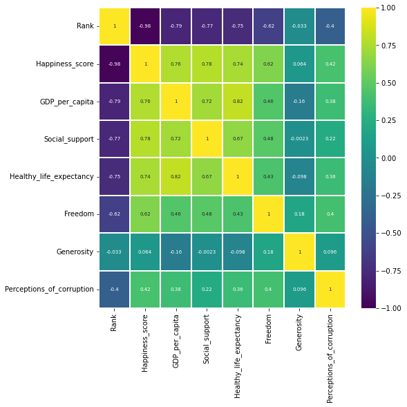

```python
# Define the size of the correlation heatmap
plt.figure(figsize=(8,8))

# Plot & display the correlation heatmap
sns.heatmap(happiness.corr(),linewidths=.1,cmap="viridis", vmin=-1, vmax=1, annot=True, annot_kws={"size": 7})
plt.yticks(rotation=0);
```

## Correlation between happiness and Freedom

Further evidence is depicted in the below graph

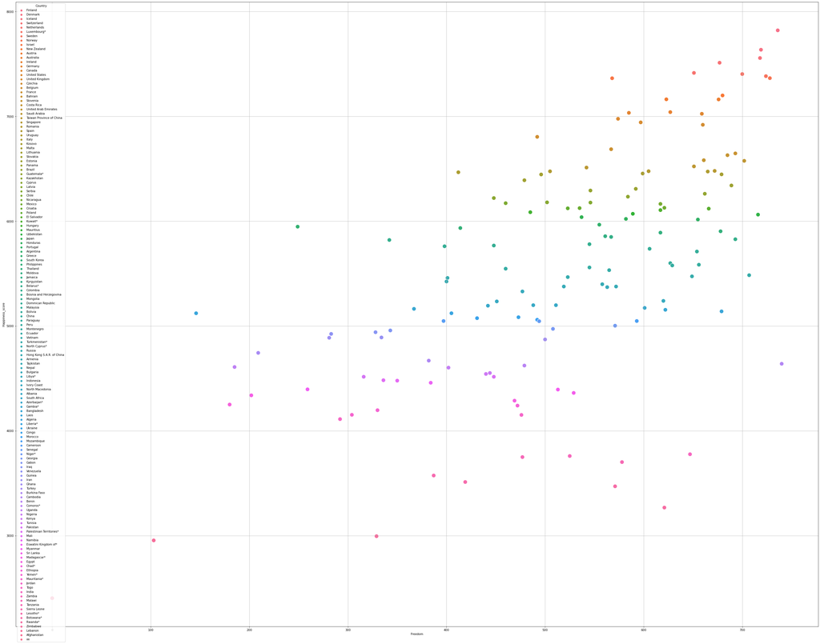

```python
# Define the size of the scatter plot
plt.figure(figsize=(50,40))

# Plot & display the scatter plot showing the comparison between happiness & freedom (to make life choices)
sns.scatterplot(data=happiness, x="Freedom", y="Happiness_score", hue="Country", s=200)
plt.grid()
```

## Is the happiest countries the freest?

1. Finland is ranked the happiest country based on its happiness index score
2. Luxembourg* is ranked highest in G.D.P. per capita; on average, the nation's citizens earn a high rate
3. Iceland is ranked as having the highest level of support accessible to an individual through social ties to other individuals, groups, and the larger community
4. Hong Kong S.A.R. of China has the highest rate of life expectancy
5. Cambodia offers its citizens the most freedom to make choices
6. Indonesia is ranked as the most generous
7. Singapore has the highest level of perceived corruption

```python
# Create a Dataframe with the countries with the highest index scores for each of the refrence factors in the dataset
highest = happiness.loc[happiness['Country'].isin(["Finland", "Luxembourg", "Iceland", "Hong Kong S.A.R. of China",
                                                   "Cambodia", "Indonesia", "Singapore"])]

# Display the new DataFrame
highest
```

|  | Rank | Country | Happiness_score | GDP_per_capita | Social_support | Healthy_life_expectancy | Freedom | Generosity | Perceptions_of_corruption |
| --- | --- | --- | --- | --- | --- | --- | --- | --- | --- |
| 0 | 1.0 | Finland | 7821.0 | 1892.0 | 1258.0 | 775.0 | 736.0 | 109.0 | 534.0 |
| 2 | 3.0 | Iceland | 7557.0 | 1936.0 | 1320.0 | 803.0 | 718.0 | 270.0 | 191.0 |
| 26 | 27.0 | Singapore | 6480.0 | 2149.0 | 1127.0 | 851.0 | 672.0 | 163.0 | 587.0 |
| 80 | 81.0 | Hong Kong S.A.R. of China | 5425.0 | 1957.0 | 954.0 | 942.0 | 400.0 | 147.0 | 383.0 |
| 86 | 87.0 | Indonesia | 5240.0 | 1382.0 | 883.0 | 539.0 | 620.0 | 468.0 | 47.0 |
| 113 | 114.0 | Cambodia | 4640.0 | 1019.0 | 732.0 | 505.0 | 740.0 | 166.0 | 68.0 |

## Summary

Is there a correlation between happiness and freedom?

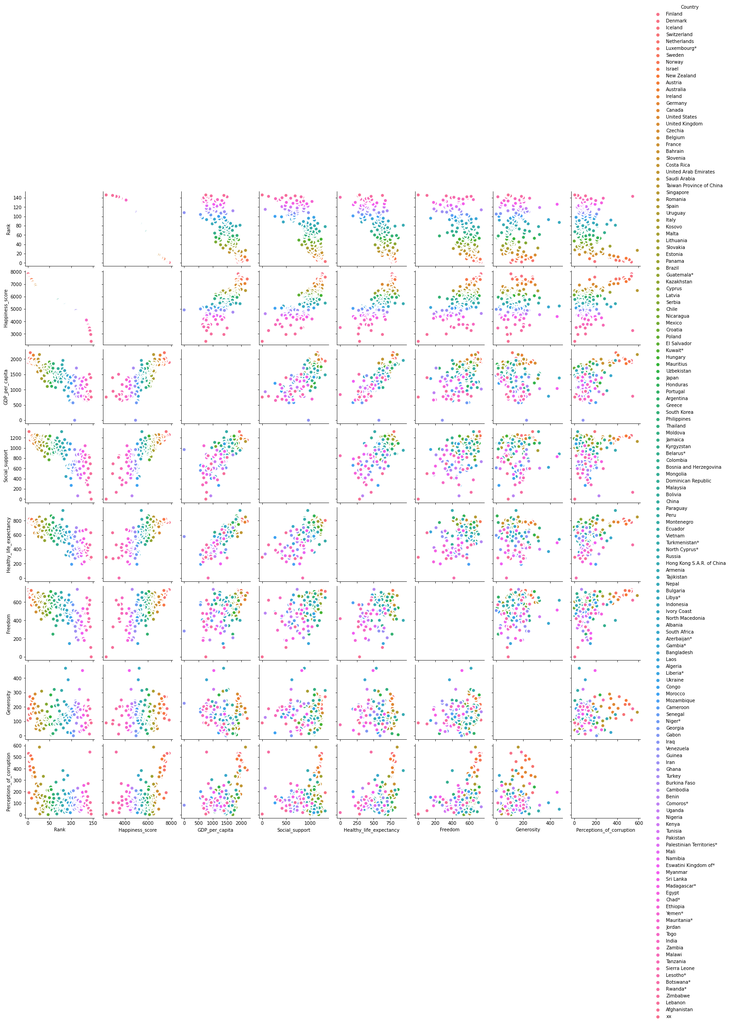

```python
# Define the size of the scatter plot
plt.figure(figsize=(50,40))

# Plot & display the pairplot plot showing the comparison
sns.pairplot(happiness, kind="scatter", hue="Country", plot_kws=dict(s=80, edgecolor="white", linewidth=2.5))
plt.show()
```

# Is the ‘free world’ population happier than the population in communist countries?

We have concluded that there is no definitive correlation between happiness and freedom; This begs the question are the communist countries happier than the free world. Let's explore!

We have compiled a list of the communist countries from the DataFrame. However, we could not find any credible information in our dataset or on the internet regarding Cuba's and North Korea's ranking – no surprise! Nonetheless, we will make a comparison between the free world & the communist country's happiness index score.

```python
# Identify all of the communist countries in the dataset
communist = happiness.loc[happiness['Country'].isin(['China', 'Cuba', 'Laos', 'North Korea','Vietnam'])]

# Display the communist countries
communist
```

|  | Rank | Country | Happiness_score | GDP_per_capita | Social_support | Healthy_life_expectancy | Freedom | Generosity | Perceptions_of_corruption |
| --- | --- | --- | --- | --- | --- | --- | --- | --- | --- |
| 71 | 72.0 | China | 5585.0 | 1508.0 | 958.0 | 705.0 | 656.0 | 99.0 | 142.0 |
| 76 | 77.0 | Vietnam | 5485.0 | 1252.0 | 932.0 | 611.0 | 707.0 | 143.0 | 105.0 |
| 94 | 95.0 | Laos | 5140.0 | 1239.0 | 654.0 | 479.0 | 679.0 | 197.0 | 184.0 |

## Averages for the variables for the communist countries

```python
# Calculate the average of the happiness. GDP, Social support, Healthy life expectancy,freedom,
# perception of corruption index scores  index score respectively for the communist countries.
comm_avg = communist[["Happiness_score", "GDP_per_capita", "Social_support",
                      "Healthy_life_expectancy","Freedom", "Perceptions_of_corruption"]].mean()

# Display the avgs
comm_avg
```

```
Happiness_score              5403.333333
GDP_per_capita               1333.000000
Social_support                848.000000
Healthy_life_expectancy       598.333333
Freedom                       680.666667
Perceptions_of_corruption     143.666667
dtype: float64
```

## Averages for the variables for the 'free world' countries

```python
# Calculate the average of the happiness. GDP, Social support, Healthy life expectancy,freedom,
# perception of corruption index scores  index score respectively for the 'free world' countries.
free_avg = free_world[["Happiness_score", "GDP_per_capita", "Social_support",
                      "Healthy_life_expectancy","Freedom", "Perceptions_of_corruption"]].mean()

# Display the avgs
free_avg
```

```
Happiness_score              5556.727273
GDP_per_capita               1412.069930
Social_support                907.076923
Healthy_life_expectancy       585.916084
Freedom                       513.797203
Perceptions_of_corruption     155.013986
dtype: float64
```

## Comparison of the variables averages between the 'free world' & the communist countries

While happiness, GDP, and social support may be higher in the free world. We must note that the index scores for life expectancy and freedom are higher in the communist countries.

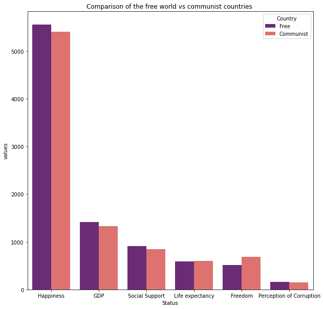

```python
# Set the figure size
plt.figure(figsize=(10, 10))

# Plot grouped barplot
sns.barplot(x="Status", y="Value", hue="Country", data=freevscomm, ci=None, palette="magma");

# Add title and axis names
plt.title('Comparison of the free world vs communist countries ')
plt.xlabel('Status')
plt.ylabel('values')
```

# Conclusion

## Is there a correlation between freedom and happiness? Is the ‘free world’ population happier than the population in communist countries?

### Is the ‘free world’ population happier than the population in communist countries?

Yes, on average, the ‘free world’ nations are happier than the communist countries; however, the differences between the margins are not significant.

# Thank You!

## I do hope that you enjoyed my analysis of this topic